# Practical Machine Learning: Course Project

Jean-Paul Courneya

1/4/2018

## Executive Summary

Using devices such as Jawbone Up, Nike FuelBand, and Fitbit it is now possible to collect a large amount of data about personal activity relatively inexpensively.

Six participants were asked to perform one set of 10 repetitions of the Unilateral Dumbbell Biceps Curl in five different fashions: exactly according to the specification (Class A), throwing the elbows to the front (Class B), lifting the dumbbell only halfway (Class C), lowering the dumbbell only halfway (Class D) and throwing the hips to the front (Class E).

This report describes how the data captured are used for predicting the manner in which exercise was done.

The training data were divided into two groups, a training data and validation. The validation set will validate the training model with an expected out-of-sample error rate of less than 0.5%, or 99.5% accuracy which would be acceptable for testing before it is used to perform the prediction on the 20 test cases - that must have 100% accuracy.

## I - Environment Prep

```r
library(caret)
```

```r
library(knitr)
library(rpart)
library(rpart.plot)
library(randomForest)
library(corrplot)
set.seed(8675309)
```

## II - Download and Pre-Process data

Download data from the URL provided. When reading in the file, change invalid values to NA.

### IIA - Download the Data

```r
trainURL <- 'https://d396qusza40orc.cloudfront.net/predmachlearn/pml-training.csv'
testURL <- 'https://d396qusza40orc.cloudfront.net/predmachlearn/pml-testing.csv'
download.file(trainURL,destfile = 'trainset.csv')
download.file(testURL,destfile = 'testset.csv')
```

### IIB - Read the data

##### Training data

```r
training <- read.csv('trainset.csv', na.strings=c('NA','#DIV/0!',''))
dim(training)
```

```
## [1] 19622   160
```

##### Testing data

```r
testing <- read.csv('testset.csv', na.strings=c('NA','#DIV/0!',''))
dim(testing)
```

```
## [1]  20 160
```

### IIC - Process the Training data

##### Create a partition within the training dataset

```r
inTrain  <- createDataPartition(training$classe, p=0.7, list=FALSE)
TrainSet <- training[inTrain, ]
ValidationSet  <- training[-inTrain, ]
dim(TrainSet)
```

```
## [1] 13737   160
```

```r
dim(ValidationSet)
```

```
## [1] 5885  160
```

##### Remove variables with Nearly Zero Variance

```r
NZV <- nearZeroVar(TrainSet)
TrainSet <- TrainSet[, -NZV]
ValidationSet  <- ValidationSet[, -NZV]
dim(TrainSet)
```

```
## [1] 13737   129
```

```r
dim(ValidationSet)
```

```
## [1] 5885  129
```

##### Remove variables that are mostly NA

```r
AllNA    <- sapply(TrainSet, function(x) mean(is.na(x))) > 0.95
TrainSet <- TrainSet[, AllNA==FALSE]
ValidationSet  <- ValidationSet[, AllNA==FALSE]
dim(TrainSet)
```

```
## [1] 13737    59
```

```r
dim(ValidationSet)
```

```
## [1] 5885   59
```

##### Remove identification only variables (columns 1 to 5)

```r
TrainSet <- TrainSet[, -(1:5)]
ValidationSet  <- ValidationSet[, -(1:5)]
dim(TrainSet)
```

```
## [1] 13737    54
```

```r
dim(ValidationSet)
```

```
## [1] 5885   54
```

##### Create working datasets from processed data.

```r
TrainSetWorking <- TrainSet
ValidationSetWorking <- ValidationSet
dim(TrainSetWorking)
```

```
## [1] 13737    54
```

```r
dim(ValidationSetWorking)
```

```
## [1] 5885   54
```

## III - Correlation Analysis

Take a look at the correlation among variables.

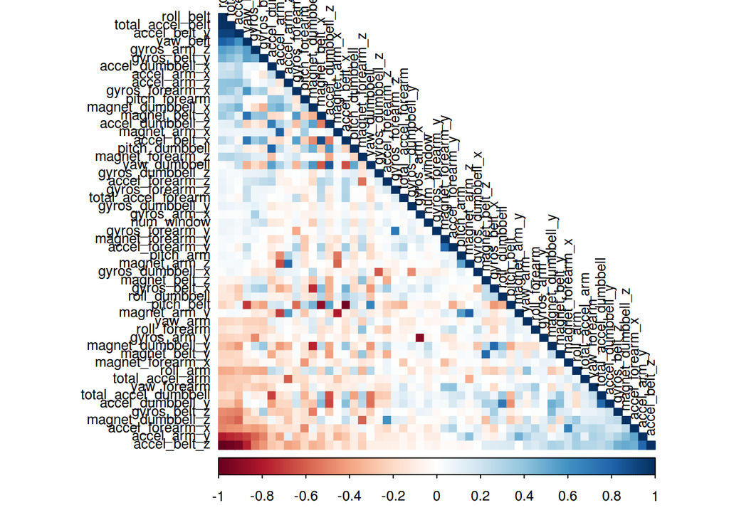

```r
corMatrix <- cor(TrainSetWorking[, -54])
corrplot(corMatrix, order = "FPC", method = "color", type = "lower",
         tl.cex = 0.8, tl.col = rgb(0, 0, 0))
```

## IV - Prediction model (using random forest)

In this step a prediction model is created using the Random Forest method. For the final knitted document I have chosen to not evaluate this chunk of code. When running the code for reproducibility this will have to be evaluated to continue processing data according to the layed out strategy.

```r
fit <- train(classe ~ ., method = "rf", data = TrainSetWorking)
save(fit, file = "modelFit.RData")
```

## IV - Measure the Accuracy and Sample Error of the prediction model

##### IV-A Training Data evaluation

Here a prediction will be created using the training set. Then we’ll measure it’s accuracy.

```r
load(file = "modelFit.RData", verbose = TRUE)
```

```
## Loading objects:
##   fit
```

```r
predTrain <- predict(fit, TrainSetWorking)
```

```r
confusionMatrix(predTrain, TrainSetWorking$classe)
```

```
## Confusion Matrix and Statistics
##
##           Reference
## Prediction    A    B    C    D    E
##          A 3906    0    0    0    0
##          B    0 2658    0    0    0
##          C    0    0 2396    0    0
##          D    0    0    0 2252    0
##          E    0    0    0    0 2525
##
## Overall Statistics
##
##                Accuracy : 1
##                  95% CI : (0.9997, 1)
##     No Information Rate : 0.2843
##     P-Value [Acc > NIR] : < 2.2e-16
##
##                   Kappa : 1
##  Mcnemar's Test P-Value : NA
##
## Statistics by Class:
##
##                      Class: A Class: B Class: C Class: D Class: E
## Sensitivity            1.0000   1.0000   1.0000   1.0000   1.0000
## Specificity            1.0000   1.0000   1.0000   1.0000   1.0000
## Pos Pred Value         1.0000   1.0000   1.0000   1.0000   1.0000
## Neg Pred Value         1.0000   1.0000   1.0000   1.0000   1.0000
## Prevalence             0.2843   0.1935   0.1744   0.1639   0.1838
## Detection Rate         0.2843   0.1935   0.1744   0.1639   0.1838
## Detection Prevalence   0.2843   0.1935   0.1744   0.1639   0.1838
## Balanced Accuracy      1.0000   1.0000   1.0000   1.0000   1.0000
```

##### IV-B Validation Data evaluation

```r
predValidation <- predict(fit, ValidationSetWorking)
confusionMatrix(predValidation, ValidationSetWorking$classe)
```

```
## Confusion Matrix and Statistics
##
##           Reference
## Prediction    A    B    C    D    E
##          A 1672    4    0    0    0
##          B    1 1133    0    0    0
##          C    0    2 1026    2    0
##          D    0    0    0  961    0
##          E    1    0    0    1 1082
##
## Overall Statistics
##
##                Accuracy : 0.9981
##                  95% CI : (0.9967, 0.9991)
##     No Information Rate : 0.2845
##     P-Value [Acc > NIR] : < 2.2e-16
##
##                   Kappa : 0.9976
##  Mcnemar's Test P-Value : NA
##
## Statistics by Class:
##
##                      Class: A Class: B Class: C Class: D Class: E
## Sensitivity            0.9988   0.9947   1.0000   0.9969   1.0000
## Specificity            0.9991   0.9998   0.9992   1.0000   0.9996
## Pos Pred Value         0.9976   0.9991   0.9961   1.0000   0.9982
## Neg Pred Value         0.9995   0.9987   1.0000   0.9994   1.0000
## Prevalence             0.2845   0.1935   0.1743   0.1638   0.1839
## Detection Rate         0.2841   0.1925   0.1743   0.1633   0.1839
## Detection Prevalence   0.2848   0.1927   0.1750   0.1633   0.1842
## Balanced Accuracy      0.9989   0.9973   0.9996   0.9984   0.9998
```

Using the validation subset to test the prediction model the accuracy is high at 99%. The out of sample error rate is very low at 0.0019.

The following lists important predictors from the model. Also included is a summary of the prediction model.

```r
varImp(fit)
```

```
## rf variable importance
##
##   only 20 most important variables shown (out of 53)
##
##                      Overall
## num_window           100.000
## roll_belt             67.128
## pitch_forearm         39.680
## yaw_belt              31.985
## magnet_dumbbell_y     31.765
## magnet_dumbbell_z     29.931
## pitch_belt            28.410
## roll_forearm          24.522
## accel_dumbbell_y      13.125
## accel_forearm_x       11.418
## roll_dumbbell         10.815
## magnet_dumbbell_x      9.700
## total_accel_dumbbell   9.621
## accel_belt_z           8.495
## accel_dumbbell_z       8.224
## magnet_belt_z          7.502
## magnet_belt_y          6.949
## magnet_forearm_z       6.868
## magnet_belt_x          5.845
## roll_arm               5.514
```

```r
fit$finalModel
```

```
##
## Call:
##  randomForest(x = x, y = y, mtry = param$mtry)
##                Type of random forest: classification
##                      Number of trees: 500
## No. of variables tried at each split: 27
##
##         OOB estimate of  error rate: 0.19%
## Confusion matrix:
##      A    B    C    D    E  class.error
## A 3906    0    0    0    0 0.0000000000
## B    7 2648    2    1    0 0.0037622272
## C    0    6 2390    0    0 0.0025041736
## D    0    0    8 2244    0 0.0035523979
## E    0    0    0    2 2523 0.0007920792
```

With the OOB Estimated Error of .19% and the high accuracy of the model using the validation data it is safe to proceed with applying the model to the testing data

## V Apply the prediction model to the test data

The last thing to do is run the test data and see how good the prediction model performed. Evaluation for this chunk is turned off.

```r
predTesting <- predict(fit, newdata = testing)
predTesting
```